# Primary School Data

#### M16a: GOF

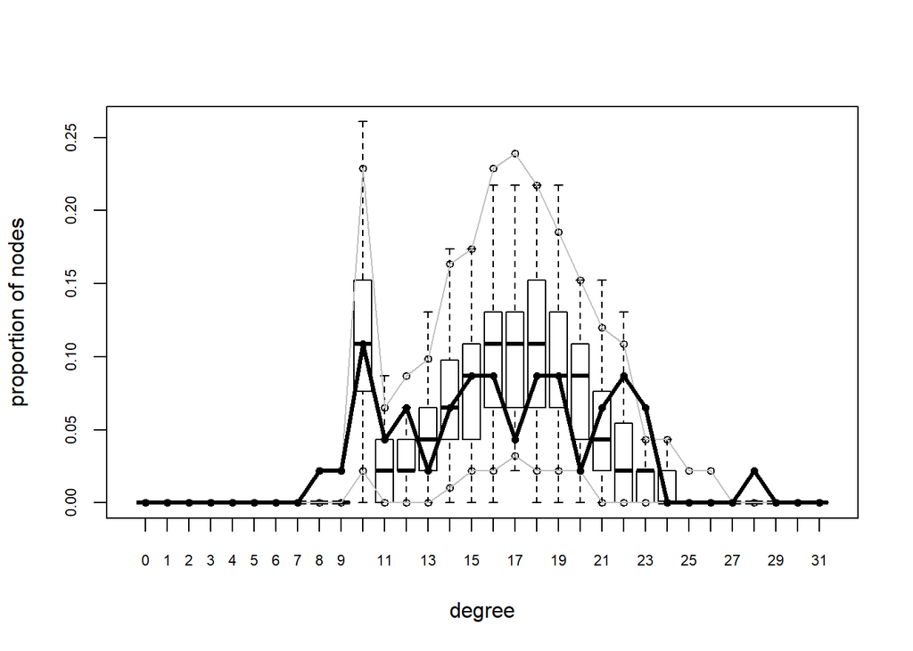

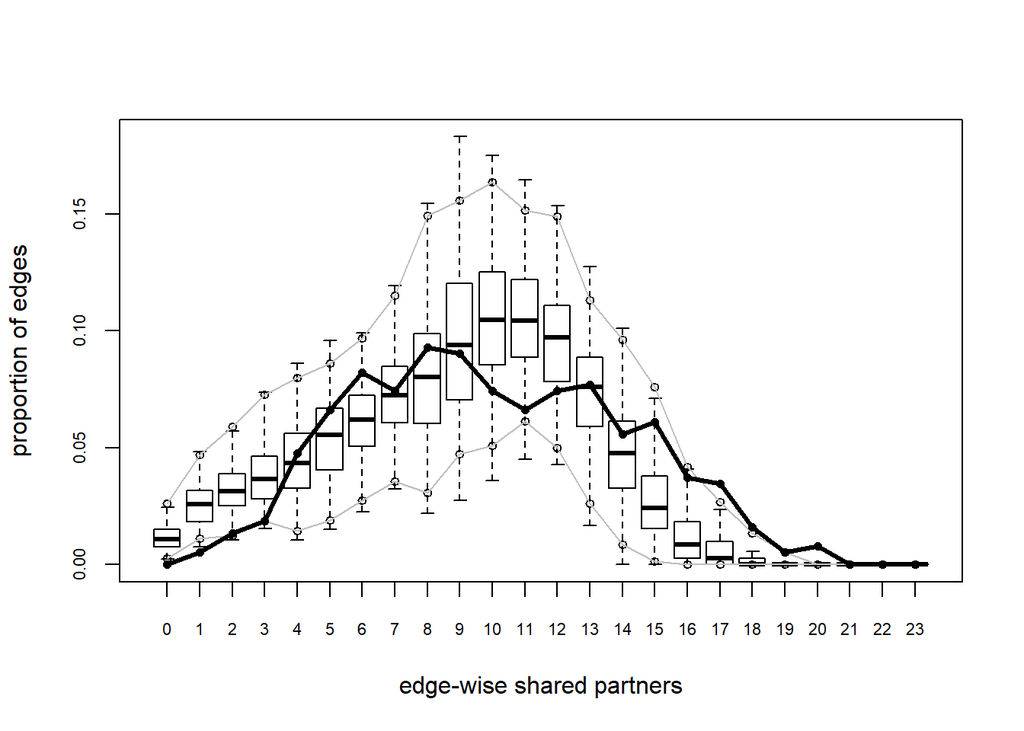

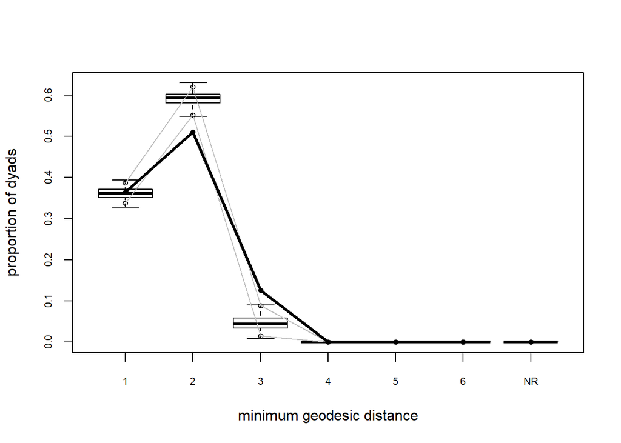

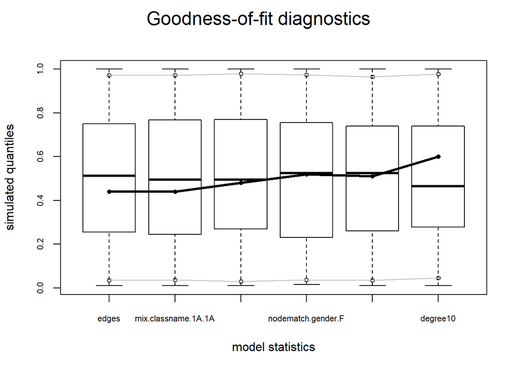

```r
plot(gof(gr1.m16a))
```

#### M16a: Diagnostics

```r
mcmc.diagnostics(gr1.m16a,center = F)
```

```
## Sample statistics summary:
##
## Iterations = 1e+05:122965000
## Thinning interval = 15000
## Number of chains = 1
## Sample size per chain = 8192
##
## 1. Empirical mean and standard deviation for each variable,
##    plus standard error of the mean:
##
##                        Mean     SD Naive SE Time-series SE
## edges               366.954 15.299  0.16903        0.16903
## mix.classname.1A.1A 118.757  8.858  0.09787        0.10271
## mix.classname.1A.1B  39.592  6.625  0.07320        0.07442
## nodematch.gender.F   98.674  6.971  0.07702        0.07702
## nodematch.gender.M   96.485  6.393  0.07064        0.07064
## degree10              7.238  2.865  0.03165        0.03283
##
## 2. Quantiles for each variable:
##
##                     2.5% 25% 50% 75% 97.5%
## edges                338 357 367 377   398
## mix.classname.1A.1A  103 112 118 125   138
## mix.classname.1A.1B   27  35  39  44    53
## nodematch.gender.F    85  94  99 103   112
## nodematch.gender.M    84  92  96 101   109
## degree10               2   5   7   9    13
##
##
## Sample statistics cross-correlations:
##                          edges mix.classname.1A.1A mix.classname.1A.1B
## edges                1.0000000           0.6853184           0.6017508
## mix.classname.1A.1A  0.6853184           1.0000000           0.2408210
## mix.classname.1A.1B  0.6017508           0.2408210           1.0000000
## nodematch.gender.F   0.5593644           0.3468487           0.3426071
## nodematch.gender.M   0.5396769           0.3776293           0.4130002
## degree10            -0.7132587          -0.7944564          -0.4301225
##                     nodematch.gender.F nodematch.gender.M   degree10
## edges                       0.55936438         0.53967687 -0.7132587
## mix.classname.1A.1A         0.34684869         0.37762928 -0.7944564
```

[output cut: 24 more lines]

```
##
## Fraction in 1st window = 0.1
## Fraction in 2nd window = 0.5
##
##               edges mix.classname.1A.1A mix.classname.1A.1B
##             -0.2835             -0.5410             -1.0064
##  nodematch.gender.F  nodematch.gender.M            degree10
##             -0.1673              0.4224              0.3535
##
## Individual P-values (lower = worse):
##               edges mix.classname.1A.1A mix.classname.1A.1B
##           0.7767589           0.5884758           0.3142006
##  nodematch.gender.F  nodematch.gender.M            degree10
##           0.8671157           0.6727055           0.7236956
## Joint P-value (lower = worse):  0.8211387 .
```

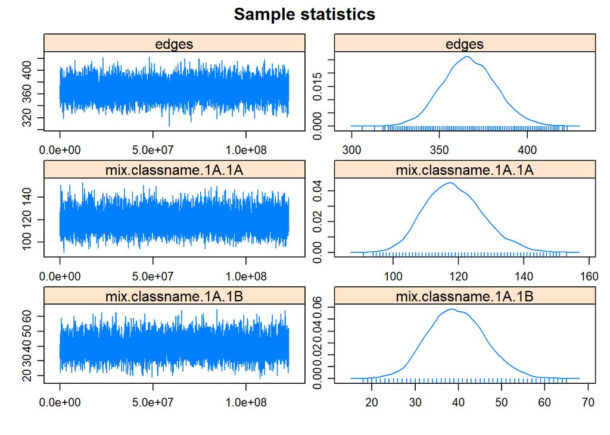

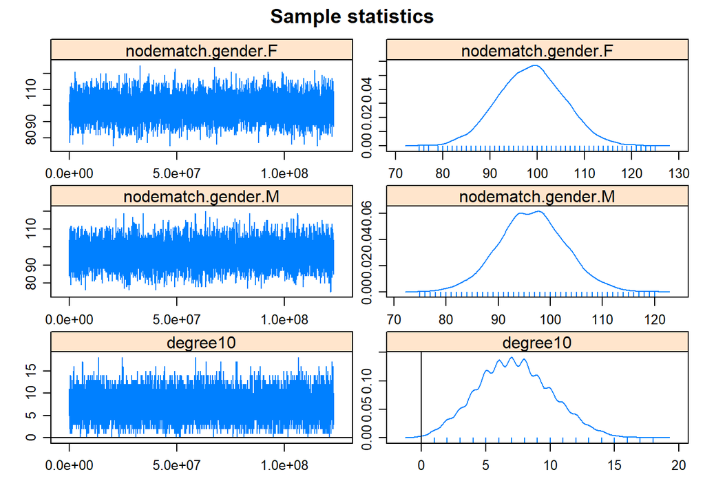

[output not shown]

### Implement Model 16a to Grade 1 network of day-2

```r
load('grade1-day2-models.Rdata')
```

```r
#M16a
#gr1.d2.m16a <- ergm(gr1.d2~edges + nodemix('classname',base=c(3))+
#                      nodematch('gender',diff=T) + degree(10),
#                    control = control.ergm(MCMC.burnin = 150000,MCMC.interval = 25000))
summary(gr1.d2.m16a)
```

```
##
## ==========================
## Summary of model fit
## ==========================
##
## Formula:   gr1.d2 ~ edges + nodemix("classname", base = c(3)) + nodematch("gender",
##     diff = T) + degree(10)
##
## Iterations:  2 out of 20
##
## Monte Carlo MLE Results:
##                     Estimate Std. Error MCMC % p-value
## edges                 0.7129     0.1509      0  <1e-04 ***
## mix.classname.1A.1A  -0.8657     0.1956      0  <1e-04 ***
## mix.classname.1A.1B  -5.7350     0.5143      0  <1e-04 ***
## nodematch.gender.F   -0.1796     0.2141      0  0.4017
## nodematch.gender.M    0.6643     0.2440      0  0.0066 **
## degree10              0.4412     0.5108      0  0.3880
## ---
## Signif. codes:  0 '***' 0.001 '**' 0.01 '*' 0.05 '.' 0.1 ' ' 1
##
##      Null Deviance: 1434.8  on 1035  degrees of freedom
##  Residual Deviance:  699.9  on 1029  degrees of freedom
##
## AIC: 711.9    BIC: 741.6    (Smaller is better.)
```

#### M16a: Day2 GOF

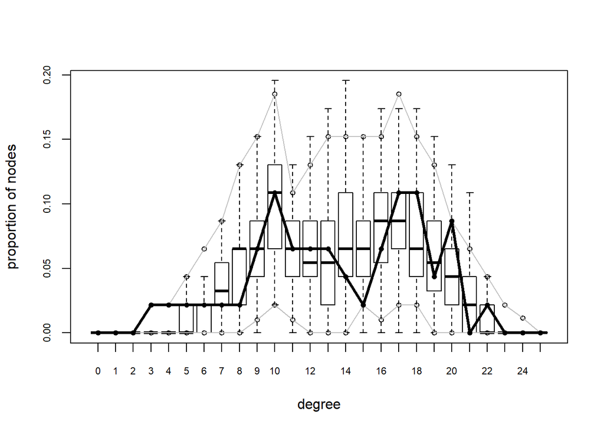

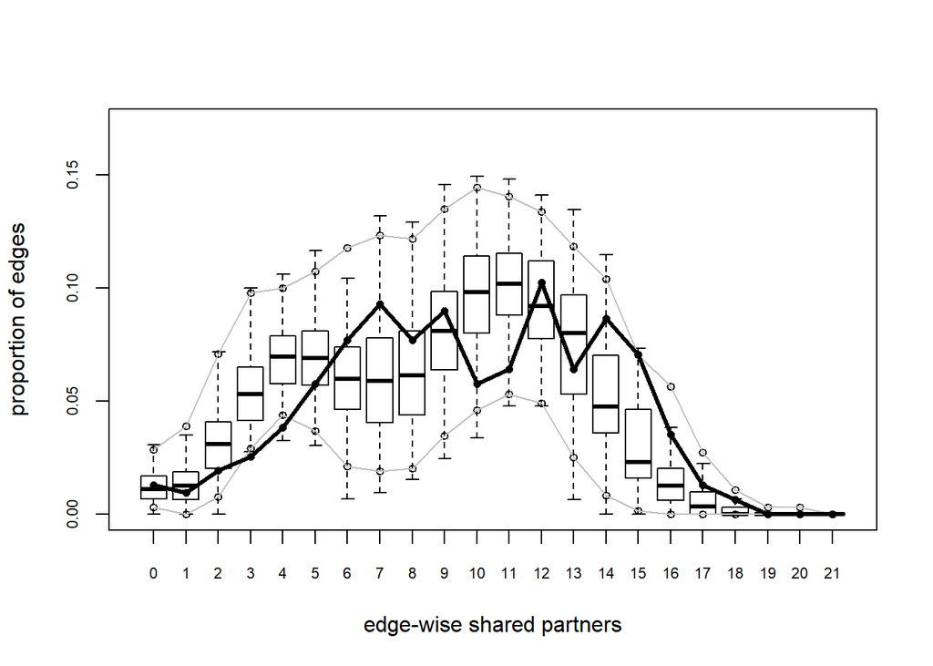

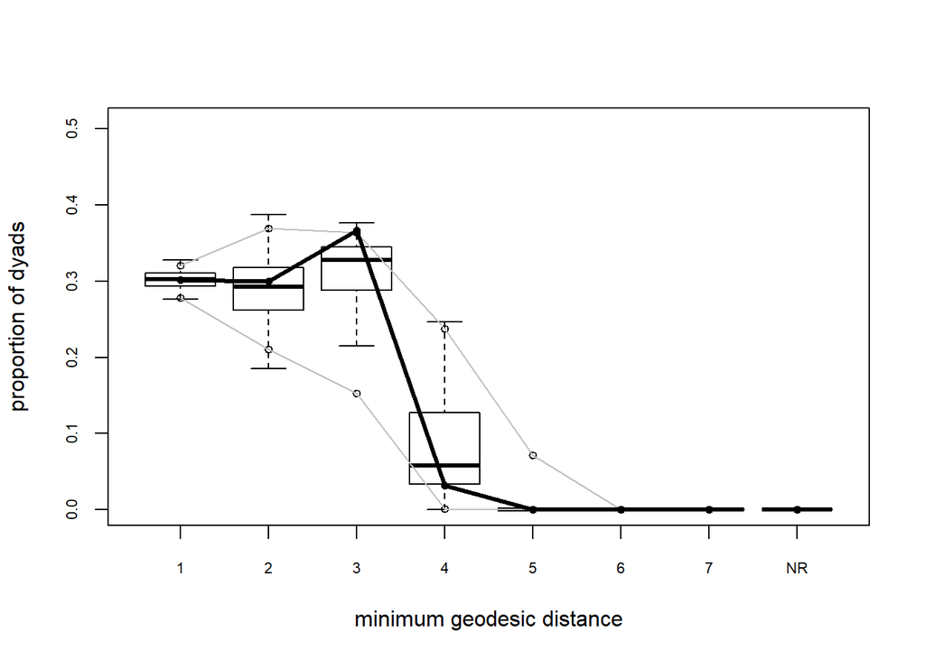

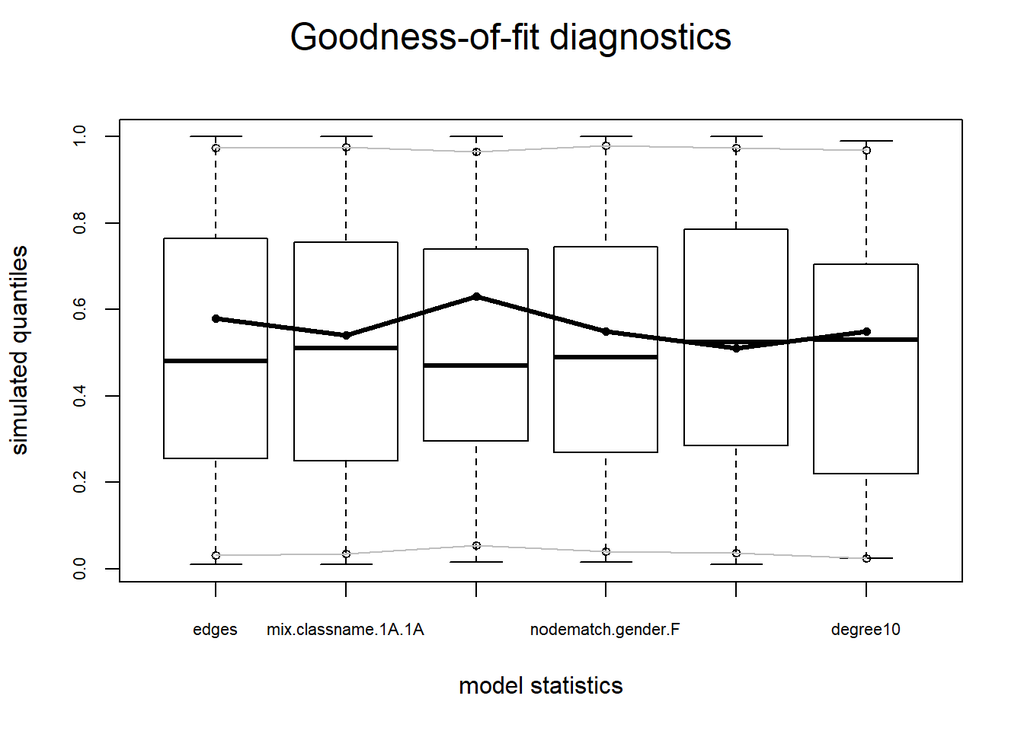

```r
plot(gof(gr1.d2.m16a))
```

#### M16a: Diagnostics

```r
mcmc.diagnostics(gr1.d2.m16a,center=F)
```

```
## Sample statistics summary:
##
## Iterations = 150000:102525000
## Thinning interval = 25000
## Number of chains = 1
## Sample size per chain = 4096
##
## 1. Empirical mean and standard deviation for each variable,
##    plus standard error of the mean:
##
##                        Mean     SD Naive SE Time-series SE
## edges               311.801 10.960  0.17124        0.17124
## mix.classname.1A.1A 102.002  6.880  0.10751        0.10449
## mix.classname.1A.1B   4.077  2.016  0.03150        0.03150
## nodematch.gender.F   72.870  5.757  0.08995        0.08995
## nodematch.gender.M   82.003  4.830  0.07547        0.07375
## degree10              5.053  1.979  0.03092        0.03092
##
## 2. Quantiles for each variable:
##
##                     2.5% 25% 50% 75% 97.5%
## edges                290 304 312 319   333
## mix.classname.1A.1A   89  97 102 107   115
## mix.classname.1A.1B    1   3   4   5     8
## nodematch.gender.F    62  69  73  77    84
## nodematch.gender.M    72  79  82  85    91
## degree10               2   4   5   6     9
##
##
## Sample statistics cross-correlations:
##                           edges mix.classname.1A.1A mix.classname.1A.1B
## edges                1.00000000         0.654067797         0.173524141
## mix.classname.1A.1A  0.65406780         1.000000000        -0.005960528
## mix.classname.1A.1B  0.17352414        -0.005960528         1.000000000
## nodematch.gender.F   0.52356784         0.313203216         0.049974740
## nodematch.gender.M   0.44494077         0.319598367         0.173305680
## degree10            -0.03689151         0.019755806        -0.002670953
##                     nodematch.gender.F nodematch.gender.M     degree10
## edges                      0.523567840        0.444940769 -0.036891507
## mix.classname.1A.1A        0.313203216        0.319598367  0.019755806
```

[output cut: 24 more lines]

```
##
## Fraction in 1st window = 0.1
## Fraction in 2nd window = 0.5
##
##               edges mix.classname.1A.1A mix.classname.1A.1B
##             0.73076             0.60160             0.04353
##  nodematch.gender.F  nodematch.gender.M            degree10
##             0.62993            -0.16410             1.25041
##
## Individual P-values (lower = worse):
##               edges mix.classname.1A.1A mix.classname.1A.1B
##           0.4649283           0.5474436           0.9652788
##  nodematch.gender.F  nodematch.gender.M            degree10
##           0.5287411           0.8696487           0.2111487
## Joint P-value (lower = worse):  0.8548799 .
```

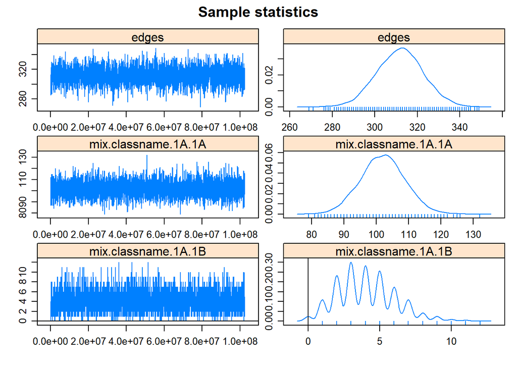

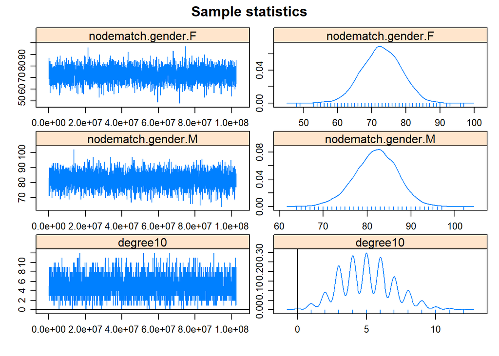

[output not shown]

### Simulated versions of Day 1 and Day 2 Models

The pink nodes represent Female students and blue nodes represent Male students. The two groups visible in the graph are for class A and B.

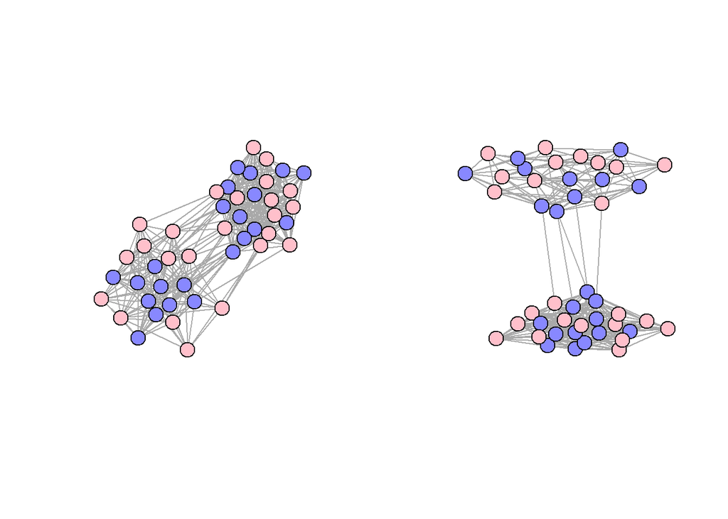

```r
#Visualize the models for both days
source('project-utils.R')
#visualization for grade1-day1 model
par(mfrow=c(1,2))
gaplot(asIgraph(simulate(gr1.m16)),names = F)
#visualization for grade1-day2 model
gaplot(asIgraph(simulate(gr1.d2.m16)),names = F)
```

```r
par(mfrow=c(1,1))
```

### Edge Probability of Female-Female edge vs Male-Male edge for both days

```r
#Calculate probability of F-F edge vs M-M edge
cases <- c( 'F-F edge','M-M edge')
edges <- c(1)
FF <- c(1,0)
MM <- c(0,1)
cases.df1 <- data.frame(Case = cases,edges=edges,FF,MM,Day = 'day1')

cases.df1$logodds <- gr1.m16$coef[1]*cases.df1$edges + gr1.m16$coef[4] * cases.df1$FF + gr1.m16$coef[5]*cases.df1$MM
cases.df1$cond_prob <- invlogit(cases.df1$logodds)

cases.df2 <- data.frame(Case = cases, edges,FF,MM,Day='day2')

cases.df2$logodds <- gr1.d2.m16$coef[1]*cases.df2$edges + gr1.d2.m16$coef[4] * cases.df2$FF + gr1.d2.m16$coef[5]*cases.df2$MM
cases.df2$cond_prob <- invlogit(cases.df2$logodds)

cases.df <- rbind(cases.df1,cases.df2)

cases.df[order(cases.df$cond_prob),]
```

```
##       Case edges FF MM  Day   logodds cond_prob
## 3 F-F edge     1  1  0 day2 0.5267517 0.6287252
## 1 F-F edge     1  1  0 day1 0.9794754 0.7270041
## 2 M-M edge     1  0  1 day1 1.3446855 0.7932594
## 4 M-M edge     1  0  1 day2 1.3670337 0.7969005
```

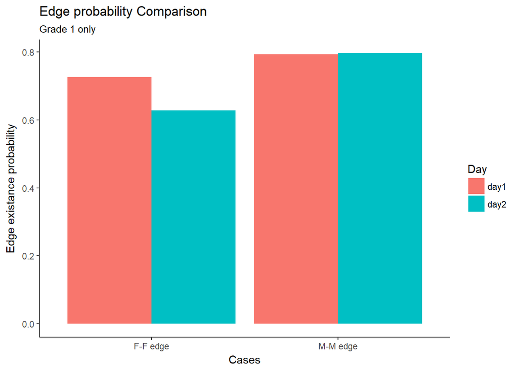

```r
#Comparison of edge conditional probability for day 1-2
g  <- ggplot(data = cases.df, aes(x=Case,y=cond_prob,fill=Day))+
  geom_bar(stat = 'identity',position = 'dodge') +
  scale_x_discrete('Cases') + scale_y_continuous('Edge existance probability') +
  ggtitle('Edge probability Comparison', subtitle = 'Grade 1 only')
plot(g)
```

For grade 1 network, the edge probability is high for Male-Male nodes for both the days. Males have almost same interaction for both days within grade 1 network. For Females interacted less on day2 as compared to day1.

### ERGM Limitations

The above ERGM model only simulates the Grade1 network. We should know that there are total 5 grades where these stats may be different. These grades have exhibit both inter-grade and intra-grade connections. Hence, this model and finding should not be genralized for any other part of the network or whole network.

### Future Works

We can try to fit this model one by one on each grade seperately and try to fit this model for 2grades at a time. If this works then we may be able to study the network characteristics more accurately.